# An Introduction to Qiskit Machine Learning

[figure not shown]

**Adaptations of notebooks originally authored by:** Anna Phan, IBM Quantum - Australia and Anton Dekusar, IBM Quantum - IBM Research Europe - Dublin

# Contents

- Overview of Qiskit Machine Learning
- Classification Example Data
- Data Encoding
- Quantum Support Vector Machine
- Variational Quantum Classifier

# Overview of Qiskit Machine Learning

[figure not shown]

# Support Vector Machine

# Classification Problem

Supervised binary classification train set: $T = \{\mathbf{x}_1, \mathbf{x}_2, ..., \mathbf{x}_M\}, \: \mathbf{x}_i \in \mathbb{R}^s$ class map: $c_{T} \rightarrow \{+1, -1\}$ test set: $S = \{\mathbf{x}_1', \mathbf{x}_2', ..., \mathbf{x}_m'\}$  
A classification map for all $\mathbf{x}$ is unknown: map: $c: \mathbf{x} \rightarrow \{+1, -1\}, \, \forall \mathbf{x}$  
Goal: find a class map $\widetilde{c} : T \cup \ S \rightarrow \{+1, -1\}\,$ that agrees well with the unknown map $c$ determining all true labels.

[figure not shown]

# Support Vector Machine

Linear decision function $$ \widetilde{c}_{\text{SVM}}(\mathbf{x}) = \mathrm{sign}(\mathbf{w}^T\mathbf{x} - b) $$ This only works for linearly separable data Objective is to maximize the margin $$ \min_{\mathbf{w} \in \mathbb{R}^s, \, b \in \mathbb{R}} ||\mathbf{w}||^2 \\ \text{s. t. } y_i(\mathbf{w}^T \mathbf{x}_i - b) \geq 1 $$

[figure not shown]

# Kernelized SVM

Introduce a nonlinear feature transformation $$ \phi : \mathbb{R}^s \rightarrow \ \mathcal{V}, \text{ where} \mathcal{V} \text{ a Hilbert space} \\ \widetilde{c}_{\text{SVM}}(\mathbf{x}) = \mathrm{sign}(\langle \mathbf{w}, \phi({\mathbf{x})}\rangle_{\nu} - b) $$ Linear in feature space, but nonlinear in the original space Kernel trick is to rewrite the SVM problem to only explicitly depend on $$ k(\mathbf{x}, \mathbf{x'}) = \langle\phi{(\mathbf{x})}, \phi{(\mathbf{x'})}\rangle_{\nu} $$ not the feature vectors $\phi(\mathbf{x})$.

[figure not shown]

# Kernelized SVM

Original data $$\mathbf{x} \in \mathbb{R}^2$$ Feature map $$\phi(\mathbf{x}) = (x_1, x_2, x_1^2 + x_2^2) \in \mathbb{R}^3$$ Kernel $$k(\mathbf{x}, \mathbf{x'}) = \phi(\mathbf{x}) \cdot \phi(\mathbf{x'}) = \mathbf{x} \cdot \mathbf{x'} + ||\mathbf{x}||^2 ||\mathbf{x'}||^2$$

[figure not shown]

# Classification Example Data

```python
import matplotlib.pyplot as plt
import numpy as np

from qiskit.utils import algorithm_globals

seed = 12345
algorithm_globals.random_seed = seed
```

For this classification example, we will use:

- *ad hoc dataset* as described in [*Havlicek et al.* Nature 567, 209-212 (2019)](https://www.nature.com/articles/s41586-019-0980-2)

Let's create our train and test datasets using an utility function provided in Qiskit Machine Learning.

```python
from qiskit_machine_learning.datasets import ad_hoc_data

train_features, train_labels, test_features, test_labels, adhoc_total = ad_hoc_data(
    training_size=20,
    test_size=5,
    n=2,
    gap=0.3,
    plot_data=False, one_hot=False, include_sample_total=True
)
```

Here we define a helper function to plot our dataset.

```python
def plot_adhoc_dataset(train_features, train_labels, test_features, test_labels, adhoc_total):

    plt.figure(figsize=(8, 8))
    plt.ylim(0, 2 * np.pi)
    plt.xlim(0, 2 * np.pi)
    plt.imshow(np.asmatrix(adhoc_total).T, interpolation='nearest',
               origin='lower', cmap='RdBu', extent=[0, 2 * np.pi, 0, 2 * np.pi])

    plt.scatter(train_features[np.where(train_labels[:] == 0), 0], train_features[np.where(train_labels[:] == 0), 1],
                marker='s', facecolors='w', edgecolors='b', label="A train")
    plt.scatter(train_features[np.where(train_labels[:] == 1), 0], train_features[np.where(train_labels[:] == 1), 1],
                marker='o', facecolors='w', edgecolors='r', label="B train")
    plt.scatter(test_features[np.where(test_labels[:] == 0), 0], test_features[np.where(test_labels[:] == 0), 1],
                marker='s', facecolors='b', edgecolors='w', label="A test")
    plt.scatter(test_features[np.where(test_labels[:] == 1), 0], test_features[np.where(test_labels[:] == 1), 1],
                marker='o', facecolors='r', edgecolors='w', label="B test")

    plt.legend(bbox_to_anchor=(1.05, 1), loc='upper left', borderaxespad=0.)
    plt.title("Ad hoc dataset for classification")

    plt.show()
```

Now plot the datasets. In this notebook we have a *pre-defined* utility function for plotting datasets.

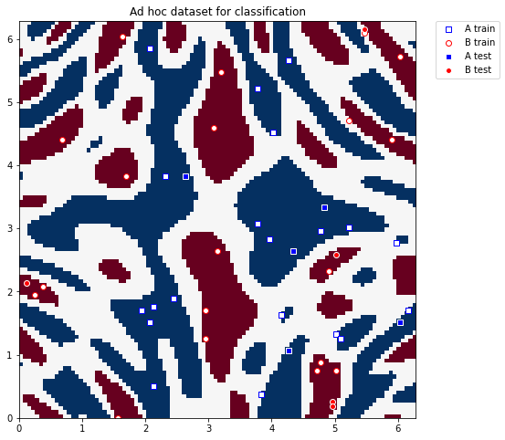

```python
plot_adhoc_dataset(train_features, train_labels, test_features, test_labels, adhoc_total)
```

Here is an example of a datapoint from each class:

```python
print(train_features[0], train_labels[0])
print(train_features[20], train_labels[20])
```

```
[2.07345115 5.84336234] 0
[1.57079633 0.        ] 1
```

# Data Encoding

Data representation is crucial for the success of machine learning models. For classical machine learning, this question usually takes the form how to represent the data numerically, so that it can be best processed by a classical machine learning algorithm.

For quantum machine learning, this question is similar, but more fundamental: how to represent and efficiently input the data into a quantum system, so that it can be processed by a quantum machine learning algorithm. This is usually referred to as data encoding, but is also called data embedding or loading.

There are various methods for data encoding, but the one generally used is arbitary encoding, which encodes 𝑁 features as rotations on 𝑁 parameterized gates on 𝑛 qubits, where 𝑛≤𝑁. It only encodes one datapoint at a time, rather than a whole dataset and uses a constant depth quantum circuit and 𝑛≤𝑁 qubits, meaning it can be run on current quantum hardware.

# Data Encoding Examples

For example, to use the Qiskit [**`EfficientSU2`**](https://qiskit.org/documentation/stubs/qiskit.circuit.library.EfficientSU2.html) circuit to encode 12 features, would only use 3 qubits:

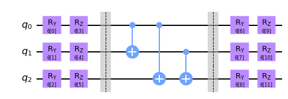

```python
from qiskit.circuit.library import EfficientSU2

circuit = EfficientSU2(num_qubits=3, reps=1, insert_barriers=True)
circuit.decompose().draw(output='mpl')
```

Here we encode the datapoint $x = [0.1,0.2,0.3,0.4,0.5,0.6,0.7,0.8,0.9,1.0,1.1,1.2]$ with 12 features, using each of the parameterized gates to encode a different feature.

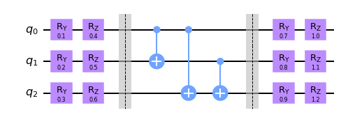

```python
x = [0.1,0.2,0.3,0.4,0.5,0.6,0.7,0.8,0.9,1.0,1.1,1.2]

encode = circuit.bind_parameters(x)
encode.decompose().draw(output='mpl')
```

The Qiskit [**`ZZFeatureMap`**](https://qiskit.org/documentation/stubs/qiskit.circuit.library.ZZFeatureMap.html) circuit with 3 qubits, only encodes a datapoint of 3 features, despite having 6 parameterized gates:

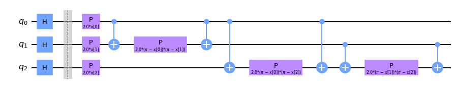

```python
from qiskit.circuit.library import ZZFeatureMap

circuit = ZZFeatureMap(3, reps=1, insert_barriers=True)
circuit.decompose().draw(output='mpl')
```

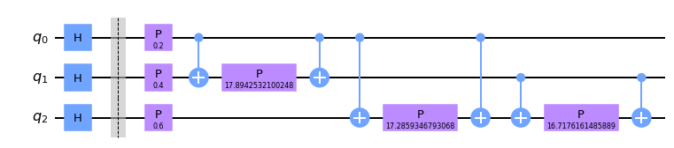

```python
x = [0.1,0.2,0.3]

encode = circuit.bind_parameters(x)
encode.decompose().draw(output='mpl')
```

The choice of which parameterized quantum circuit to use to encode what data is an active area of research.

### Exercise 1: Data Encoding Encode the data point $x = (-0.1,0.2)$ using the `ZZFeatureMap` with 4 repetitions and default data mapping function.

```python
x = [-0.1,0.2]
# YOUR CODE HERE
```

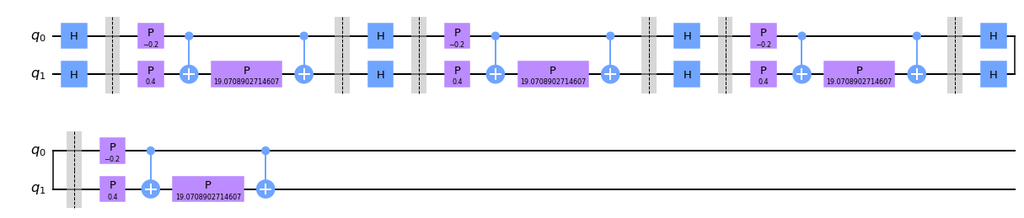

```python
x = [-0.1,0.2]
# YOUR CODE HERE

encode_map = ZZFeatureMap(feature_dimension=2, reps=4, entanglement='linear', insert_barriers=True)
ex1_circuit = encode_map.bind_parameters(x)
ex1_circuit.decompose().draw("mpl")
```

# Quantum Support Vector Machine

Introduced in [*Havlicek et al.* Nature 567, 209-212 (2019)](https://www.nature.com/articles/s41586-019-0980-2), the quantum support vector classification algorithm consists of these steps:

[figure not shown]

1. Build the train and test quantum kernel matrices.
   1. For each pair of datapoints in the training dataset $\mathbf{x}_{i},\mathbf{x}_j$, apply the feature map and measure the transition probability: $ K_{ij} = \left| \langle 0 | \mathbf{U}^\dagger_{\Phi(\mathbf{x_j})} \mathbf{U}_{\Phi(\mathbf{x_i})} | 0 \rangle \right|^2 $.
   2. For each training datapoint $\mathbf{x_i}$ and testing point $\mathbf{y_i}$, apply the feature map and measure the transition probability: $ K_{ij} = \left| \langle 0 | \mathbf{U}^\dagger_{\Phi(\mathbf{y_i})} \mathbf{U}_{\Phi(\mathbf{x_i})} | 0 \rangle \right|^2 $.
2. Use the train and test quantum kernel matrices in a classical support vector machine classification algorithm.